## Using Method I with XGBoost Classifier

In this section, we evaluate model performance using **Method I** for dataset splitting, where data from 2015–2016 is used for training and data from January to June 2017 is used for testing. We applied **feature importance from caret::varImp** for feature selection before model training, and used **XGBoost** as the classifier.

### Resort Hotel

For the **Resort Hotel**, we apply the correct sampling ratios: **SMOTE (1:0.6)** and **DownSampling (1.5:1)** as specified in the methodology.

```
##
## not_canceled     canceled
##        13368         8020
```

[output not shown]

[output not shown]

```r
library(pROC)

# === 使用哪個模型與資料集（可換成 validation_selected）
chosen_model <- model_smote
chosen_data <- test_selected

# 取得預測機率
probs <- predict(chosen_model, newdata = chosen_data[, top_features, drop = FALSE], type = "prob")[, "canceled"]

# 真實標籤 (1 = canceled, 0 = not_canceled)
truth <- if (is.factor(chosen_data$is_canceled)) {
  as.numeric(chosen_data$is_canceled == "canceled")
} else {
  as.numeric(chosen_data$is_canceled)
}

# 計算 ROC 曲線
roc_obj <- roc(response = truth, predictor = probs, quiet = TRUE)

# 找出最佳 threshold（以最大 Youden index 為準）
opt <- coords(roc_obj, x = "best", best.method = "youden", ret = c("threshold", "sensitivity", "specificity", "precision", "recall", "f1"))

# 顯示最佳 cut-off 資訊
print(opt)
```

```
##           threshold sensitivity specificity precision    recall
## threshold 0.2954182   0.7893373   0.7372906 0.5396102 0.7893373
```

```r
library(pROC)

# === 使用哪個模型與資料集（可換成 validation_selected）
chosen_model <- model_downsample
chosen_data <- test_selected

# 取得預測機率
probs <- predict(chosen_model, newdata = chosen_data[, top_features, drop = FALSE], type = "prob")[, "canceled"]

# 真實標籤 (1 = canceled, 0 = not_canceled)
truth <- if (is.factor(chosen_data$is_canceled)) {
  as.numeric(chosen_data$is_canceled == "canceled")
} else {
  as.numeric(chosen_data$is_canceled)
}

# 計算 ROC 曲線
roc_obj <- roc(response = truth, predictor = probs, quiet = TRUE)

# 找出最佳 threshold（以最大 Youden index 為準）
opt <- coords(roc_obj, x = "best", best.method = "youden", ret = c("threshold", "sensitivity", "specificity", "precision", "recall", "f1"))

# 顯示最佳 cut-off 資訊
print(opt)
```

```
##           threshold sensitivity specificity precision    recall
## threshold 0.3023104   0.7611996   0.7681976 0.5615952 0.7611996
```

```r
# ==== Step 10: Compile Results Table ====

resort_results <- data.frame(
  Hotel = "Resort Hotel",
  Method = rep(c("SMOTE", "DownSample"), each = 2),
  Dataset = rep(c("Validation", "Test"), 2),
  Accuracy = c(
    if (!is.null(validation_results_smote)) validation_results_smote$Accuracy else NA,
    if (!is.null(test_results_smote)) test_results_smote$Accuracy else NA,
    validation_results_downsample$Accuracy,
    test_results_downsample$Accuracy
  ),
  Precision = c(
    if (!is.null(validation_results_smote)) validation_results_smote$Precision else NA,
    if (!is.null(test_results_smote)) test_results_smote$Precision else NA,
    validation_results_downsample$Precision,
    test_results_downsample$Precision
  ),
  Recall = c(
    if (!is.null(validation_results_smote)) validation_results_smote$Recall else NA,
    if (!is.null(test_results_smote)) test_results_smote$Recall else NA,
    validation_results_downsample$Recall,
    test_results_downsample$Recall
  ),
  F1_Score = c(
    if (!is.null(validation_results_smote)) validation_results_smote$F1_Score else NA,
    if (!is.null(test_results_smote)) test_results_smote$F1_Score else NA,
    validation_results_downsample$F1_Score,
    test_results_downsample$F1_Score
  ),
  AUC = c(
    if (!is.null(validation_results_smote)) validation_results_smote$AUC else NA,
    if (!is.null(test_results_smote)) test_results_smote$AUC else NA,
    validation_results_downsample$AUC,
    test_results_downsample$AUC
  )
)

# 顯示表格
kable(resort_results,
      caption = "Resort Hotel Performance Comparison: Validation vs Test Sets",
      digits = 4)
```

Resort Hotel Performance Comparison: Validation vs Test Sets

| Hotel | Method | Dataset | Accuracy | Precision | Recall | F1_Score | AUC |
| --- | --- | --- | --- | --- | --- | --- | --- |
| Resort Hotel | SMOTE | Validation | 0.7868 | 0.5926 | 0.6575 | 0.6234 | 0.8544 |
| Resort Hotel | SMOTE | Test | 0.7898 | 0.6170 | 0.6620 | 0.6387 | 0.8463 |
| Resort Hotel | DownSample | Validation | 0.8051 | 0.6282 | 0.6712 | 0.6490 | 0.8520 |
| Resort Hotel | DownSample | Test | 0.7920 | 0.6283 | 0.6338 | 0.6310 | 0.8470 |

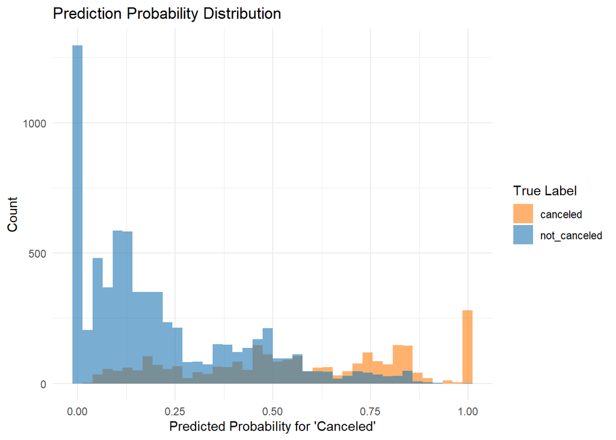

Prediction Probability Distribution for Canceled vs Not Canceled

```r
library(ggplot2)

# 選擇一個模型與測試資料（可改為 validation_selected）
chosen_model <- model_smote
chosen_data <- test_selected

# 確保是 factor，並抓出 "canceled" 預測機率
chosen_probs <- predict(chosen_model, newdata = chosen_data[, top_features, drop=FALSE], type = "prob")[, "canceled"]
truth_labels <- if (is.factor(chosen_data$is_canceled)) as.character(chosen_data$is_canceled) else as.character(factor(chosen_data$is_canceled, labels = c("not_canceled", "canceled")))

# 建圖資料
plot_df <- data.frame(prob = chosen_probs, truth = truth_labels)

# 畫圖
ggplot(plot_df, aes(x = prob, fill = truth)) +
  geom_histogram(position = "identity", bins = 40, alpha = 0.6) +
  scale_fill_manual(values = c("not_canceled" = "#1f77b4", "canceled" = "#ff7f0e")) +
  labs(title = "Prediction Probability Distribution",
       x = "Predicted Probability for 'Canceled'",
       y = "Count",
       fill = "True Label") +
  theme_minimal()
```

### City Hotel

For the **City Hotel**, we apply **SMOTE (1:0.8)** and **DownSampling (1.2:1)** ratios.

```r
df_hotel <- df_city

# Split data: 2015-2016 for training, Jan-Jun 2017 for testing
train_test_data <- df_hotel %>% filter(arrival_date < as.Date("2017-01-01"))
test_data <- df_hotel %>% filter(arrival_date >= as.Date("2017-01-01") & arrival_date < as.Date("2017-07-01"))

# Create validation split from training data (25% of each month)
validation_split <- create_validation_split(train_test_data)
train_data <- validation_split$train
validation_data <- validation_split$validation

# Remove hotel column
train_data$hotel <- NULL
validation_data$hotel <- NULL
test_data$hotel <- NULL

# Convert is_canceled to factor (0 -> "not_canceled", 1 -> "canceled")
train_data$is_canceled <- factor(train_data$is_canceled, levels = c(0,1), labels = c("not_canceled", "canceled"))
validation_data$is_canceled <- factor(validation_data$is_canceled, levels = c(0,1), labels = c("not_canceled", "canceled"))
test_data$is_canceled <- factor(test_data$is_canceled, levels = c(0,1), labels = c("not_canceled", "canceled"))


# Remove arrival_date and year_month for model fitting
train_data_for_model <- train_data %>% select(-arrival_date, -year_month)
validation_data_for_model <- validation_data %>% select(-arrival_date, -year_month)
# test_data needs arrival_date removed for model structure alignment.
# 'year_month' was not added to test_data, so it cannot be removed.
test_data_for_model_structure <- test_data %>% select(-arrival_date) # CORRECTED LINE

# Feature selection using Information Gain (caret::varImp)
train_data_for_model_complete <- train_data_for_model[complete.cases(train_data_for_model), ]

if(nrow(train_data_for_model_complete) < 2 || length(unique(train_data_for_model_complete$is_canceled)) < 2) {
    cat("Skipping varImp for City hotel due to insufficient data or variance in target.\n")
    top_features <- names(train_data_for_model_complete)[!names(train_data_for_model_complete) %in% "is_canceled"]
} else {
    model_formula <- as.formula("is_canceled ~ .")
    capture.output(
        model_caret_train <- train(model_formula, data = train_data_for_model_complete,
            method = "xgbTree",
            trControl = trainControl(method = "cv", number = 3, classProbs = TRUE),
            verbosity = 0,
            tuneGrid = expand.grid(nrounds = 50, max_depth = 3, eta = 0.1, gamma = 0, colsample_bytree = 0.8, min_child_weight = 1, subsample = 0.5)
        )
    , file = nullfile())

    importance <- varImp(model_caret_train)$importance
    top_features <- rownames(importance)[order(importance$Overall, decreasing = TRUE)][1:min(15, nrow(importance))]
}
top_features <- intersect(top_features, colnames(train_data_for_model))

# Select top features for all datasets
train_selected <- train_data_for_model[, c(top_features, "is_canceled")]
validation_selected <- validation_data_for_model[, c(top_features, "is_canceled")]
test_selected <- test_data_for_model_structure[, c(top_features, "is_canceled")]


# Ensure 'is_canceled' is factor with correct levels for SMOTE input
train_selected$is_canceled <- factor(train_selected$is_canceled, levels=c("not_canceled", "canceled"))

# Apply sampling with correct ratios
# SMOTE: 1:0.8 (Cancel:Not Cancel) -> over_ratio = 0.8
smote_train <- apply_smote_with_ratio(train_selected[complete.cases(train_selected), ])

# DownSampling: 1.2:1 (Cancel:Not Cancel) -> N_majority_new / N_minority_original = 1.2
train_selected_numeric <- train_selected
train_selected_numeric$is_canceled <- as.numeric(train_selected_numeric$is_canceled) - 1 # not_canceled=0, canceled=1
downsample_train <- apply_downsample_with_ratio(train_selected_numeric[complete.cases(train_selected_numeric), ])

# Train models
cat("Training XGBoost models for City Hotel...\n")
xgb_smote <- train_xgb(smote_train, "is_canceled")
xgb_downsample <- train_xgb(downsample_train, "is_canceled")

# Prepare labels for evaluation (numeric 0/1)
validation_label <- as.numeric(validation_selected$is_canceled) - 1
test_label <- as.numeric(test_selected$is_canceled) - 1

# Evaluate on validation set
cat("Evaluating City Hotel on validation set...\n")
validation_results_smote <- evaluate_model(xgb_smote, validation_selected[, top_features, drop=FALSE], validation_label)
validation_results_downsample <- evaluate_model(xgb_downsample, validation_selected[, top_features, drop=FALSE], validation_label)

# Evaluate on test set
cat("Evaluating City Hotel on test set...\n")
test_results_smote <- evaluate_model(xgb_smote, test_selected[, top_features, drop=FALSE], test_label)
test_results_downsample <- evaluate_model(xgb_downsample, test_selected[, top_features, drop=FALSE], test_label)

# Create comprehensive results table
city_results <- data.frame(
  Hotel = "City Hotel",
  Method = rep(c("SMOTE (1:0.8)", "DownSample (1.2:1)"), each = 2),
  Dataset = rep(c("Validation", "Test"), 2),
  Accuracy = c(validation_results_smote$Accuracy, test_results_smote$Accuracy,
               validation_results_downsample$Accuracy, test_results_downsample$Accuracy),
  Precision = c(validation_results_smote$Precision, test_results_smote$Precision,
                validation_results_downsample$Precision, test_results_downsample$Precision),
  Recall = c(validation_results_smote$Recall, test_results_smote$Recall,
             validation_results_downsample$Recall, test_results_downsample$Recall),
  F1_Score = c(validation_results_smote$F1_Score, test_results_smote$F1_Score,
               validation_results_downsample$F1_Score, test_results_downsample$F1_Score),
  AUC = c(validation_results_smote$AUC, test_results_smote$AUC,
          validation_results_downsample$AUC, test_results_downsample$AUC)
)

kable(city_results,
      caption = "City Hotel Performance Comparison: Validation vs Test Sets",
      digits = 4)
```

[output not shown]

### Combined Results Summary

```r
# Combine all results
all_results <- rbind(resort_results, city_results)

# Save all_results to CSV
write.csv(all_results, "all_results.csv", row.names = FALSE)
cat("Saved all_results to all_results.csv\n")

kable(all_results,
      caption = "Complete Performance Comparison: XGBoost with Method I",
      digits = 4)

# Calculate performance gaps
gap_analysis <- all_results %>%
  select(Hotel, Method, Dataset, Accuracy, AUC) %>%
  pivot_wider(names_from = Dataset, values_from = c(Accuracy, AUC)) %>%
  mutate(
    Accuracy_Gap = round((Accuracy_Validation - Accuracy_Test) * 100, 2),
    AUC_Gap = round((AUC_Validation - AUC_Test) * 100, 2)
  ) %>%
  select(Hotel, Method, Accuracy_Gap, AUC_Gap)

# Save gap_analysis to CSV
write.csv(gap_analysis, "gap_analysis.csv", row.names = FALSE)
cat("Saved gap_analysis to gap_analysis.csv\n")

kable(gap_analysis,
      caption = "Performance Gap Analysis: Validation vs Test (Percentage Points)",
      col.names = c("Hotel", "Method", "Accuracy Gap (%)", "AUC Gap (%)"))
```

[output not shown]

### Load and Display Combined Results from File

This chunk can be used to load and display the `all_results` table from the saved CSV file. You can set `eval=FALSE` for this chunk in your R Markdown document if you want to rely on the pre-computed file.

```r
# This chunk is intended to potentially have eval=FALSE in the final document
# Load and display all_results from file
if (file.exists("all_results.csv")) {
  loaded_all_results <- read.csv("all_results.csv")
  kable(loaded_all_results,
        caption = "Complete Performance Comparison: XGBoost with Method I (loaded from file)",
        digits = 4)
} else {
  cat("all_results.csv not found. Run the 'combined-results' chunk first to generate the file.\n")
}
```

Complete Performance Comparison: XGBoost with Method I (loaded from file)

[output not shown]

### Load and Display Gap Analysis from File

This chunk can be used to load and display the `gap_analysis` table from the saved CSV file. You can set `eval=FALSE` for this chunk.

```r
# This chunk is intended to potentially have eval=FALSE in the final document
# Load and display gap_analysis from file
if (file.exists("gap_analysis.csv")) {
  loaded_gap_analysis <- read.csv("gap_analysis.csv")
  kable(loaded_gap_analysis,
        caption = "Performance Gap Analysis: Validation vs Test (Percentage Points) (loaded from file)",
        col.names = c("Hotel", "Method", "Accuracy Gap (%)", "AUC Gap (%)"))
} else {
  cat("gap_analysis.csv not found. Run the 'combined-results' chunk first to generate the file.\n")
}
```

Performance Gap Analysis: Validation vs Test (Percentage Points) (loaded from file)

[output not shown]